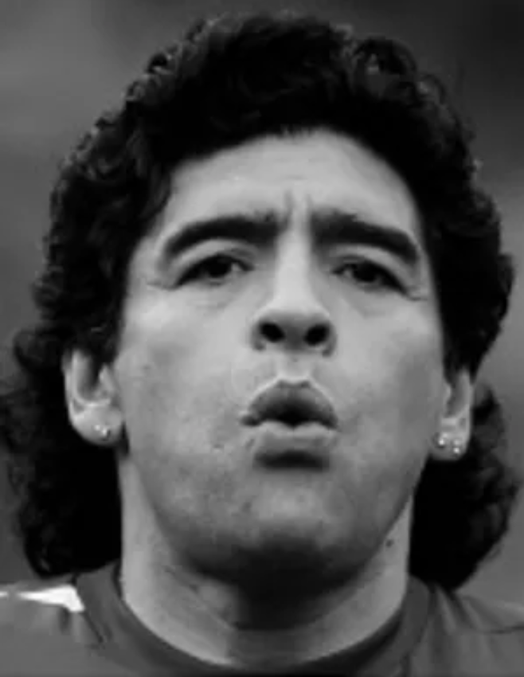

# Diego Armando Maradona

Futbolista profesional · Director técnico · Conductor

Campeón del Mundo 1986 con la Selección Argentina de fútbol. Trayectoria destacada en *Napoli*, *Barcelona*, *Boca Juniors* y *Argentinos Juniors*. Experiencia como DT de la Selección Argentina y conductor televisivo. Liderazgo, comunicación y alto rendimiento.

+54 9 11 1234567 d10s@gmail.com [www.D10S.com](https://es.wikipedia.org/wiki/La_mano_de_Dios)

## Experiencia personal

**Director técnico — Selección Argentina de Fútbol** *Asociación del Fútbol Argentino (AFA)* 2008 — 2010

- Conducción del equipo nacional en Eliminatorias y Mundial FIFA 2010.
- Gestión de plantel, estrategia de partidos y comunicación pública.

**Conductor — “La Noche del 10”** *Canal 13, Argentina* 2005

- Programa de entrevistas y entretenimiento con invitados internacionales.
- Conducción en vivo, guionado y diseño de secciones.

**Futbolista profesional — SSC Napoli (Italia)** *Serie A* 1984 — 1991

- Capitán y figura histórica del club.
- **Títulos:** Serie A 1986/87, 1989/90; Copa Italia 1986/87; **Copa UEFA 1988/89**.
- Récords de goles y asistencias; liderazgo de equipo y representación institucional.

**Futbolista profesional — FC Barcelona (España)** *La Liga* 1982 — 1984

- **Títulos:** Copa del Rey 1982/83, Copa de la Liga 1983, Supercopa de España 1983.

**Futbolista profesional — Selección Argentina** *AFA* 1977 — 1994

- **Campeón del Mundo 1986** (Balón de Oro del Mundial).
- Subcampeón del Mundo 1990.
- Más de 90 partidos internacionales oficiales.

**Futbolista profesional — Boca Juniors (Argentina)** *Primera División* 1981 — 1982

- **Campeón Metropolitano 1981**. Referente del plantel.

**Futbolista profesional — Argentinos Juniors (Argentina)** *Primera División* 1976 — 1981

- Debut profesional y máximo goleador de torneos locales (menciones 1978–1980).

## Educación

**Curso de Dirección Técnica**  
*AFA — Asociación del Fútbol Argentino* 1998 — 1999

**Formación juvenil de fútbol**  
*Escuela de Fútbol de Argentinos Juniors* 1969 — 1976

## Logros seleccionados

- **Copa Mundial FIFA 1986** — Campeón (Argentina).
- **Copa Mundial Sub-20 1979** — Campeón (Argentina Sub-20).
- **Copa UEFA 1988/89** — Campeón (SSC Napoli).
- **Serie A 1986/87 y 1989/90** — Campeón (SSC Napoli).
- **Metropolitano 1981** — Campeón (Boca Juniors).

## Distinciones individuales

- **Balón de Oro del Mundial 1986**; Equipo de las Estrellas (1986 y 1990).
- **Máximo goleador**: varios torneos locales (1978, 1979, 1980) y Copas nacionales/Serie A (1988).
- **Guerin d’Oro (1985)**; **Premio World Soccer** al mejor jugador del mundo (1986–1987).
- **Jugador del Siglo (FIFA, 2000)** — distinción compartida.
- **Once histórico del Balón de Oro (2020)**.

## Idiomas

- **Español:** lengua madre
- **Italiano:** C1

## Competencias

- **Liderazgo y capitanía:** conducción de equipos de alto rendimiento.
- **Estrategia y táctica:** planificación de juego y análisis situacional.
- **Comunicación pública:** medios, eventos y vocería institucional.
- **Mentoría:** detección y desarrollo de talento joven.

## Enlaces / Portfolio

Una selección visual que resume mi trayectoria profesional y logros.

[figure not shown]

Los comienzos — Argentinos Juniors (1976 – 1981)

[figure not shown]

Consagración — Boca Juniors (1981)

[figure not shown]

Europa — FC Barcelona (1982–84)

[figure not shown]

Época dorada — SSC Napoli (1984–91)

[figure not shown]

Gloria mundial — México 1986

[figure not shown]

El legado — Director técnico

[figure not shown]

El legado — Símbolo eterno